# Mid-Term Take Home

Sumanth Donthula

2022-10-19

Question 1)

From the scattered plots we can see that the rental rates(Y) is modarately correlated with operating_expenses(X2) and square_footage(X4).Y is weakly related with age(X1) and vacancy rates(X3).

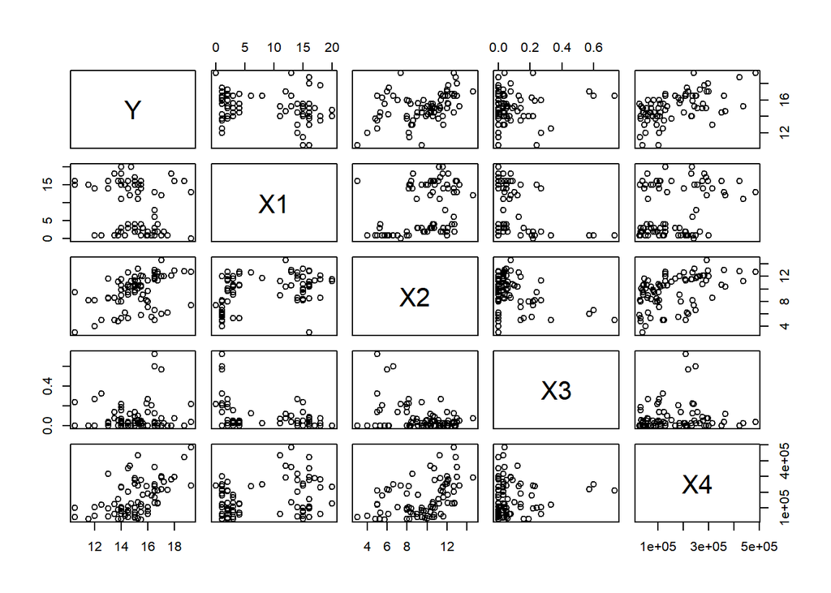

```r
Data=read.table("Commercial_Property.txt", header = TRUE, sep = "");
Y=Data$Y;
X1=Data$X1;
X2=Data$X2;
X3=Data$X3;
X4=Data$X4;


par(mfrow=c(3,2))
pairs(Data)
```

Question 2)

or

$Y=1.220e+01-1.420e-01*X1+2.820e-01*X2+6.193e-01*X3+7.924e-06*X4$

```r
Model1=lm(Y~X1+X2+X3+X4)
Model1
```

```
##
## Call:
## lm(formula = Y ~ X1 + X2 + X3 + X4)
##
## Coefficients:
## (Intercept)           X1           X2           X3           X4
##   1.220e+01   -1.420e-01    2.820e-01    6.193e-01    7.924e-06
```

Question 3)

In the first plot i.e, residuals against individual predictors, the residuals appears to form a systematic patterns and i.i.d. with normal distribution.

In the second plot i.e, residuals against two factor interaction the systematic pattern for residuals look like i.i.d. normally distributed in X2 x X4 and X1 x X2 interaction terms.

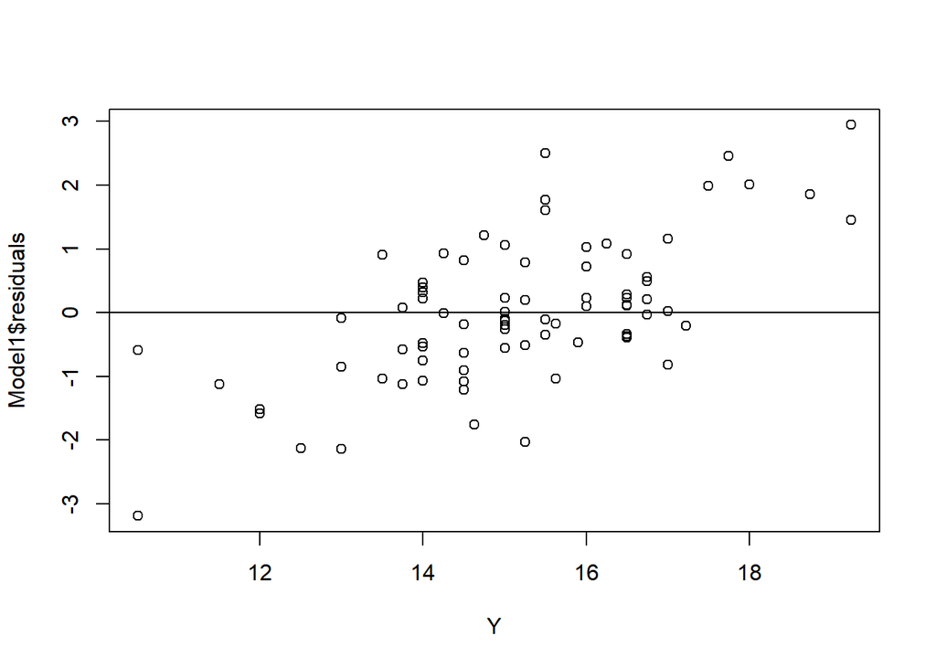

```r
plot(Y,Model1$residuals)
abline(0,0)
```

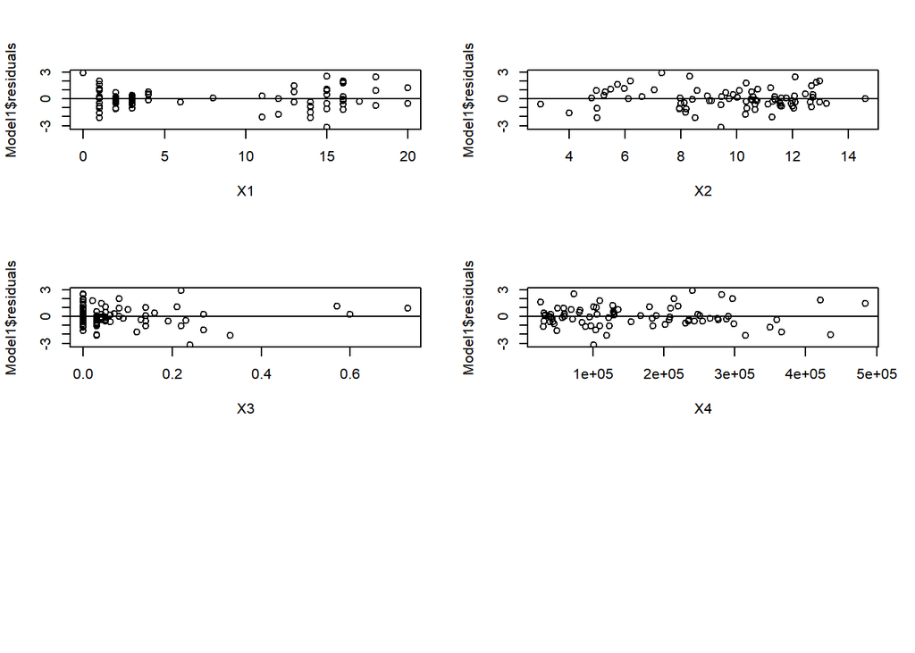

```r
par(mfrow=c(3,2))

plot(X1,Model1$residuals)
abline(0,0)
plot(X2,Model1$residuals)
abline(0,0)
plot(X3,Model1$residuals)
abline(0,0)
plot(X4,Model1$residuals)
abline(0,0)


par(mfrow=c(3,2))
```

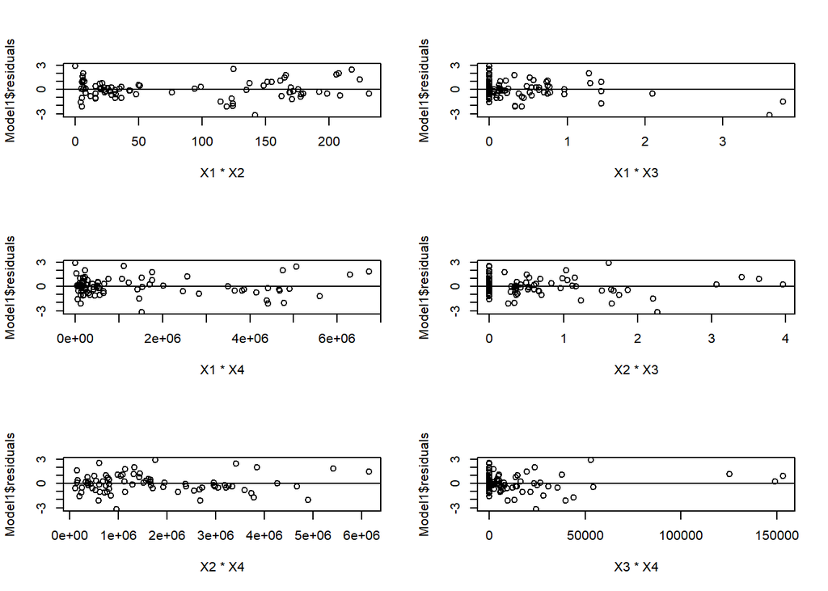

```r
plot(X1*X2,Model1$residuals)
abline(0,0)
plot(X1*X3,Model1$residuals)
abline(0,0)
plot(X1*X4,Model1$residuals)
abline(0,0)
plot(X2*X3,Model1$residuals)
abline(0,0)
plot(X2*X4,Model1$residuals)
abline(0,0)
plot(X3*X4,Model1$residuals)
abline(0,0)
```

Question 4)

```r
anova(Model1)
```

```
## Analysis of Variance Table
##
## Response: Y
##           Df Sum Sq Mean Sq F value    Pr(>F)
## X1         1 14.819  14.819 11.4649  0.001125 **
## X2         1 72.802  72.802 56.3262 9.699e-11 ***
## X3         1  8.381   8.381  6.4846  0.012904 *
## X4         1 42.325  42.325 32.7464 1.976e-07 ***
## Residuals 76 98.231   1.293
## ---
## Signif. codes:  0 '***' 0.001 '**' 0.01 '*' 0.05 '.' 0.1 ' ' 1
```

```r
Fs=qf(0.95,1,76)
Fs
```

```
## [1] 3.96676
```

Question 5)

R Square defines the variance of dependent variable that can be explained by independent variables.

R-squared : 0.5847 #from summary of the model.

Adjusted R-Squared Adjusted R-Square is similar to R-Squared but it will consider degrees of freedom of the data points also into account because the R-Squared varies a lot if new dependent variables are added.

Adjusted R-squared : 0.5629 #from summary of the model.

```r
summary(Model1)
```

```
##
## Call:
## lm(formula = Y ~ X1 + X2 + X3 + X4)
##
## Residuals:
##     Min      1Q  Median      3Q     Max
## -3.1872 -0.5911 -0.0910  0.5579  2.9441
##
## Coefficients:
##               Estimate Std. Error t value Pr(>|t|)
## (Intercept)  1.220e+01  5.780e-01  21.110  < 2e-16 ***
## X1          -1.420e-01  2.134e-02  -6.655 3.89e-09 ***
## X2           2.820e-01  6.317e-02   4.464 2.75e-05 ***
## X3           6.193e-01  1.087e+00   0.570     0.57
## X4           7.924e-06  1.385e-06   5.722 1.98e-07 ***
## ---
## Signif. codes:  0 '***' 0.001 '**' 0.01 '*' 0.05 '.' 0.1 ' ' 1
##
## Residual standard error: 1.137 on 76 degrees of freedom
## Multiple R-squared:  0.5847, Adjusted R-squared:  0.5629
## F-statistic: 26.76 on 4 and 76 DF,  p-value: 7.272e-14
```

Question 6)

The point estimates, 95 percent confidence and prediction intervals for the data points are as follows:

```r
Data1=data.frame(X1=4,X2=10,X3=0.1,X4=80000)
Data2=data.frame(X1=6,X2=11.5,X3=0,X4=120000)
Data3=data.frame(X1=12,X2=12.5,X3=0.32,X4=340000)


 writeLines("Confidence Intervals")
```

```
## Confidence Intervals
```

```r
predict(Model1, newdata = Data1, interval = "confidence", level=0.95)
```

```
##       fit      lwr     upr
## 1 15.1485 14.76829 15.5287
```

```r
predict(Model1, newdata = Data2, interval = "confidence", level=0.95)
```

```
##        fit      lwr      upr
## 1 15.54249 15.15366 15.93132
```

```r
predict(Model1, newdata = Data3, interval = "confidence", level=0.95)
```

```
##        fit      lwr     upr
## 1 16.91384 16.18358 17.6441
```

```r
writeLines("Prediction Intervals")
```

```
## Prediction Intervals
```

```r
predict(Model1, newdata = Data1, interval = "prediction", level=0.95)
```

```
##       fit      lwr     upr
## 1 15.1485 12.85249 17.4445
```

```r
predict(Model1, newdata = Data2, interval = "prediction", level=0.95)
```

```
##        fit      lwr      upr
## 1 15.54249 13.24504 17.83994
```

```r
predict(Model1, newdata = Data3, interval = "prediction", level=0.95)
```

```
##        fit      lwr      upr
## 1 16.91384 14.53469 19.29299
```

Question 7)

partial F test

Partial F Test

Conclusion: Since F Ratio is less than F statistic we don’t reject null hypothesis so $Beta3=0$

```r
Model2=lm(Y~X1+X2+X4)
Model2
```

```
##
## Call:
## lm(formula = Y ~ X1 + X2 + X4)
##
## Coefficients:
## (Intercept)           X1           X2           X4
##   1.237e+01   -1.442e-01    2.672e-01    8.178e-06
```

```r
anova(Model1)
```

```
## Analysis of Variance Table
##
## Response: Y
##           Df Sum Sq Mean Sq F value    Pr(>F)
## X1         1 14.819  14.819 11.4649  0.001125 **
## X2         1 72.802  72.802 56.3262 9.699e-11 ***
## X3         1  8.381   8.381  6.4846  0.012904 *
## X4         1 42.325  42.325 32.7464 1.976e-07 ***
## Residuals 76 98.231   1.293
## ---
## Signif. codes:  0 '***' 0.001 '**' 0.01 '*' 0.05 '.' 0.1 ' ' 1
```

```r
anova(Model2)
```

```
## Analysis of Variance Table
##
## Response: Y
##           Df Sum Sq Mean Sq F value    Pr(>F)
## X1         1 14.819  14.819  11.566  0.001067 **
## X2         1 72.802  72.802  56.825 7.841e-11 ***
## X4         1 50.287  50.287  39.251 1.973e-08 ***
## Residuals 77 98.650   1.281
## ---
## Signif. codes:  0 '***' 0.001 '**' 0.01 '*' 0.05 '.' 0.1 ' ' 1
```

```r
#From Anova Tables
SSRF=98.231
SSRR=98.650
dfF=4
dfr=3
MSEf=1.293

F=((SSRR - SSRF)/(dfF - dfr))/MSEf
F
```

```
## [1] 0.3240526
```

```r
qf(p=.95, dfF-dfr, nrow(Data)-5)
```

```
## [1] 3.96676
```

Question 8)

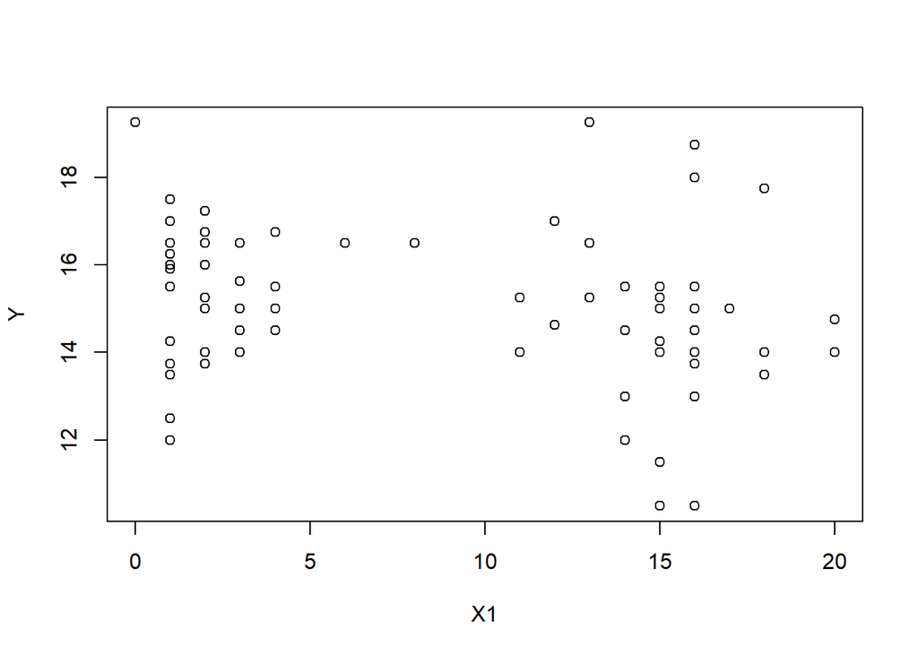

```r
plot(X1,Y)
```

Question 9)

Model3 is a good fit.

```r
XSq=X1^2
Model3=lm(Y~X1+X2+X4+XSq)
summary(Model3)
```

```
##
## Call:
## lm(formula = Y ~ X1 + X2 + X4 + XSq)
##
## Residuals:
##      Min       1Q   Median       3Q      Max
## -2.89596 -0.62547 -0.08907  0.62793  2.68309
##
## Coefficients:
##               Estimate Std. Error t value Pr(>|t|)
## (Intercept)  1.249e+01  4.805e-01  26.000  < 2e-16 ***
## X1          -4.043e-01  1.089e-01  -3.712  0.00039 ***
## X2           3.140e-01  5.880e-02   5.340 9.33e-07 ***
## X4           8.046e-06  1.267e-06   6.351 1.42e-08 ***
## XSq          1.415e-02  5.821e-03   2.431  0.01743 *
## ---
## Signif. codes:  0 '***' 0.001 '**' 0.01 '*' 0.05 '.' 0.1 ' ' 1
##
## Residual standard error: 1.097 on 76 degrees of freedom
## Multiple R-squared:  0.6131, Adjusted R-squared:  0.5927
## F-statistic:  30.1 on 4 and 76 DF,  p-value: 5.203e-15
```

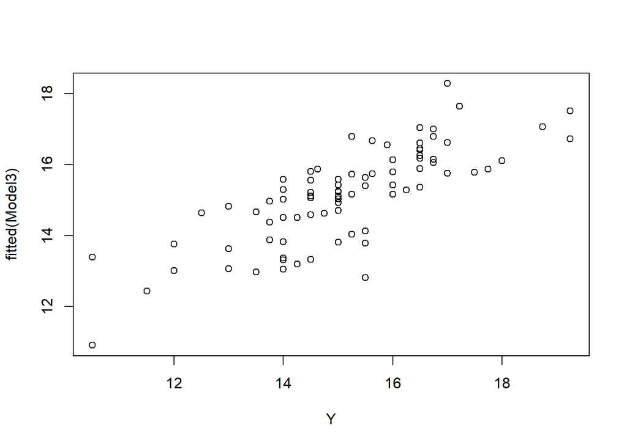

```r
plot(Y,fitted(Model3))
```

Question 10)

partial F test

Partial F Test

Conclusion: Since F Ratio is greater than F statistic so we reject null hypothesis so $X1^2$ is a significant term

```r
anova(Model2)
```

```
## Analysis of Variance Table
##
## Response: Y
##           Df Sum Sq Mean Sq F value    Pr(>F)
## X1         1 14.819  14.819  11.566  0.001067 **
## X2         1 72.802  72.802  56.825 7.841e-11 ***
## X4         1 50.287  50.287  39.251 1.973e-08 ***
## Residuals 77 98.650   1.281
## ---
## Signif. codes:  0 '***' 0.001 '**' 0.01 '*' 0.05 '.' 0.1 ' ' 1
```

```r
anova(Model3)
```

```
## Analysis of Variance Table
##
## Response: Y
##           Df Sum Sq Mean Sq F value    Pr(>F)
## X1         1 14.819  14.819 12.3036 0.0007627 ***
## X2         1 72.802  72.802 60.4463 2.968e-11 ***
## X4         1 50.287  50.287 41.7522 8.907e-09 ***
## XSq        1  7.115   7.115  5.9078 0.0174321 *
## Residuals 76 91.535   1.204
## ---
## Signif. codes:  0 '***' 0.001 '**' 0.01 '*' 0.05 '.' 0.1 ' ' 1
```

```r
#From Anova Tables
SSRR=98.650#Reduced Model
SSRF=91.535#Full Model
dfF=4
dfr=3
MSEf=1.204

#Partial test
F=((SSRR - SSRF)/(dfF - dfr))/MSEf
F
```

```
## [1] 5.909468
```

```r
qf(p=.95, dfF-dfr, nrow(Data)-5)
```

```
## [1] 3.96676
```